# LOO-CV for RV analysis: the GJ 4276 system

In this notebook we will demonstrate how to carry out leave-one-out cross-validation (LOO-CV) using the Pareto-smoothed importance sampling (PSIS) approximation. We will perform a LOO-CV analysis of CARMENES RV data for the GJ 4276 system (Nagel et al. 2019). We will use the arviz package to do so. We begin by importing the relevant packages:

```python
import numpy as np
import matplotlib.pyplot as plt
import arviz as az               #main package required for LOO-CV
from scipy.special import logsumexp

AUX_DIR  = 'auxiliary_data'
```

## 1. Posterior samples

The main object that we require for LOO-CV is the pointwise log likelihood for a set of equally-weighted posterior samples. This can be generated after an RV model fit has been completed by iterating through your equally weighted posteriors and calculating the likelihood function (without summing over data points) for each sample. Alternatively, you can generate model realisations for each sample and calculate the likelihood afterwards.

In this case, we will perform LOO-CV for two different models: a single-planet model and a two-planet model. We load the log-likelihoods here (note that you will need to download the auxiliary data and place it in the appropriate directory):

```python
#Log Likelihoods for the single-planet model
loglike_1pl = np.load(AUX_DIR+'/loglikelihood_per_datapoint_single_planet.npy')

loglike_2pl = np.load(AUX_DIR+'/loglikelihood_per_datapoint_two_planet.npy')

print(loglike_1pl.shape)
print(loglike_2pl.shape)
```

```
(92215, 100)
(89366, 100)
```

We can see that each array consists of a number of posterior samples, each with 100 values representing the likelihood function calculated for each individual RV measurement.

## 2. Formatting

In order to use the arviz `loo` function, we need to format our data appropriately. We create an object containing the log likelihoods, together with a placeholder for the posteriors (this is not needed in the LOO-CV calculation, but arviz expects the group to be present).

Note that arviz changed its interface at version 1.0: xarray's `DataTree` replaced `InferenceData`, and the per-observation scores returned by `loo` were renamed from `loo_i` to `elpd_i`. The two small helpers below let the rest of the notebook run unchanged under either version.

```python
#arviz changed its interface at version 1.0, so detect which one is installed
_ARVIZ_LEGACY = hasattr(az, 'convert_to_inference_data')
_VAR = 'x' if _ARVIZ_LEGACY else 'y'
print('arviz', az.__version__)

def make_loo_input(loglike):
    #Add a chain dimension so the array is read correctly, and attach a placeholder posterior
    ll = np.expand_dims(loglike, 0)
    if _ARVIZ_LEGACY:
        data = az.convert_to_inference_data(ll, group='log_likelihood')
        data.add_groups(posterior={"placeholder": np.ones_like(ll)})
        return data
    return az.from_dict({'log_likelihood': {_VAR: ll},
                         'posterior': {"placeholder": np.ones(ll.shape[:2])}})

def get_loo_i(result):
    #The per-observation scores are called loo_i before arviz 1.0 and elpd_i from 1.0 onwards
    return np.copy(result.elpd_i if hasattr(result, 'elpd_i') else result.loo_i)

loglike_1pl_data = make_loo_input(loglike_1pl)
loglike_2pl_data = make_loo_input(loglike_2pl)
```

```
arviz 1.1.0
```

## 3. Leave-one-out cross-validation

Now we can carry out LOO-CV. We can also check a summary of the calculation to ensure that the Pareto k diagnostics are ok. If the Pareto k value exceeds 0.7 for any data point, it is recommended to re-run your RV fit without that data point rather than relying on the PSIS approximation to calculate the expected log predictive density (ELPD). We can start with the single-planet case:

```python
loo_1pl = az.loo(loglike_1pl_data, var_name = _VAR, pointwise = True)
loo_1pl
```

```
Computed from 92215 posterior samples and 100 observations log-likelihood matrix.

         Estimate       SE
elpd_loo  -267.82    15.02
p_loo       23.69        -

There has been a warning during the calculation. Please check the results.
------

Pareto k diagnostic values:
                         Count   Pct.
(-Inf, 0.70]   (good)       99   99.0%
   (0.70, 1]   (bad)         1    1.0%
    (1, Inf)   (very bad)    0    0.0%
```

```python
loo_i_1pl = get_loo_i(loo_1pl)
print(loo_i_1pl)
```

```
[-3.38010981 -2.0260373  -2.17235367 -1.75995497 -4.56907671 -2.11503181
 -1.56025086 -2.29068774 -2.17937738 -1.75636629 -1.46657912 -4.84871969
 -2.74203788 -1.97271564 -1.5739614  -1.60509184 -1.31762366 -1.31836527
 -3.49275025 -1.85051975 -1.63436154 -2.75225105 -2.48853715 -4.74830629
 -4.24291585 -1.71232363 -2.67545784 -1.38764991 -1.6853298  -7.45644701
 -7.85903194 -3.04876132 -6.60976603 -4.12542117 -2.65517772 -2.45055696
 -1.8907195  -3.92812122 -2.71168832 -2.64456488 -4.29611843 -1.67094248
 -1.57510467 -9.72812104 -1.74941411 -3.56832678 -4.67450467 -6.08945353
 -1.69307108 -1.46080654 -2.1530715  -1.65393844 -1.76714479 -3.00974843
 -3.20901113 -2.49594817 -1.61346223 -1.62495241 -2.12672683 -1.64980846
 -2.66231028 -1.65782095 -2.32185301 -2.04318221 -1.66225127 -5.219632
 -1.95995124 -3.17664648 -1.83872461 -1.64362153 -1.74113782 -1.54109677
 -1.78410276 -1.53579572 -5.20414456 -1.50776923 -1.73628012 -3.07985368
 -2.0392818  -1.88670169 -4.05349338 -1.81307772 -2.19979158 -2.01443627
 -1.87876929 -2.51289451 -2.48324827 -1.57626421 -1.40661996 -4.58528545
 -3.53917754 -3.16660404 -1.45033686 -1.5735677  -2.30306218 -2.28928229
 -1.93363538 -2.08385652 -2.84678393 -3.35178136]
```

Now we move on to the two-planet case:

```python
loo_2pl = az.loo(loglike_2pl_data, var_name = _VAR, pointwise = True)
loo_2pl
```

```
/Users/matthewnixon/miniforge3/envs/juliet_env/lib/python3.14/site-packages/arviz_stats/loo/helper_loo.py:1146: UserWarning: Estimated shape parameter of Pareto distribution is greater than 0.70 for one or more samples. You should consider using a more robust model, this is because importance sampli…
  warnings.warn(
```

```
Computed from 89366 posterior samples and 100 observations log-likelihood matrix.

         Estimate       SE
elpd_loo  -282.72    16.12
p_loo       36.25        -

There has been a warning during the calculation. Please check the results.
------

Pareto k diagnostic values:
                         Count   Pct.
(-Inf, 0.70]   (good)       98   98.0%
   (0.70, 1]   (bad)         2    2.0%
    (1, Inf)   (very bad)    0    0.0%
```

```python
#Convert the output values of k into a numpy array
pareto_k_2pl = np.copy(loo_2pl.pareto_k)

#Check which indices yield k>0.7
print(np.argwhere(pareto_k_2pl>0.7))
```

```
[[ 4]
 [89]]
```

So, we need to refit the two-planet model to the dataset two more times, once leaving out the data point at index 4, and once leaving out the data point at index 89. Once this is done, we then evaluate the likelihood of the model fit without that data point on the data point itself. The ELPD for that point is the logarithm of the *average likelihood* across all posterior samples, i.e. $\mathrm{elpd}_i = \log \left[ S^{-1}\sum_s p(d_i|\theta^s) \right]$, which we evaluate with `logsumexp` for numerical stability. For illustrative purposes, we have provided the per-data-point log-likelihoods for our RV model fit to the data with each point removed.

```python
#Load the log-likelihoods fit to the data with points 4 and 89 removed, evaluated on the whole data set
loglike_x04 = np.load('auxiliary_data/loglikelihood_idx_4_left_out.npy')
loglike_x89 = np.load('auxiliary_data/loglikelihood_idx_89_left_out.npy')

#The ELPD score for each point is the log of the posterior-mean likelihood of the model
#fit with that data point removed, evaluated on that data point
def elpd_i(loglike_column):
    return logsumexp(loglike_column) - np.log(len(loglike_column))

loo_04 = elpd_i(loglike_x04[:,4])
loo_89 = elpd_i(loglike_x89[:,89])

#Create an array of the ELPD values from arviz, and replace the two problematic entries with the newly-computed values
loo_i_2pl_arviz = get_loo_i(loo_2pl)

loo_i_2pl = np.copy(loo_i_2pl_arviz)

loo_i_2pl[4] = loo_04
loo_i_2pl[89] = loo_89

print(loo_i_2pl)
```

```
[-2.97162631 -2.04311304 -2.25847612 -2.23825446 -5.66657458 -1.93228127
 -1.66687766 -3.18914901 -2.37079521 -2.52783795 -1.59158904 -5.92933933
 -1.89533551 -2.11532007 -1.51149537 -1.57061459 -1.35648422 -2.10045939
 -2.28610839 -2.8403058  -1.75020757 -3.20020313 -2.97551227 -3.59863942
 -6.16460448 -2.30525593 -3.0195559  -2.02230992 -1.46832463 -7.53048399
 -5.84825082 -2.38232104 -7.15491996 -4.54587658 -2.43820651 -2.27707961
 -1.87203556 -4.84934757 -2.77634717 -2.09110605 -6.91498169 -2.08866994
 -2.31443875 -9.978056   -2.47478246 -4.15553017 -3.08064723 -4.17013193
 -1.53497425 -1.5228219  -2.03586442 -2.1403989  -1.33544518 -2.47386338
 -2.92887506 -2.62750976 -1.9918521  -1.71625707 -2.20614469 -1.66333811
 -2.35683512 -1.57121803 -1.69007751 -2.16970607 -1.61565982 -4.32053961
 -2.65618313 -3.85107316 -1.86454817 -1.55515252 -2.19798761 -1.61163696
 -2.64129601 -2.12426824 -5.11090633 -1.53379872 -1.89360777 -3.76460195
 -2.02719387 -1.71817651 -3.0985563  -1.66520038 -2.50551641 -2.04877379
 -1.56978422 -3.2131379  -2.45195785 -1.68983173 -1.4386282  -3.15260829
 -6.33066013 -2.4438895  -1.42296947 -1.48887188 -2.17250647 -2.76417637
 -1.71069276 -1.54819682 -4.16422041 -5.34206179]
```

## 4. Results and plotting

Now we can calculate the difference in ELPD scores between the two models, as well as its standard error:

```python
delta_elpd_i = loo_i_1pl - loo_i_2pl

delta_elpd = np.sum(delta_elpd_i)
se_delta_elpd = np.power(len(delta_elpd_i)*np.var(delta_elpd_i),0.5)

print(f"The difference in ELPD is {delta_elpd:.2f} in favour of the single-planet model, with a standard error of {se_delta_elpd:.2f}.")
```

```
The difference in ELPD is 12.37 in favour of the single-planet model, with a standard error of 7.57.
```

Finally, we can visualise the difference in ELPD at the per-data-point level with a figure.

```
(-18.0, 18.0)
```

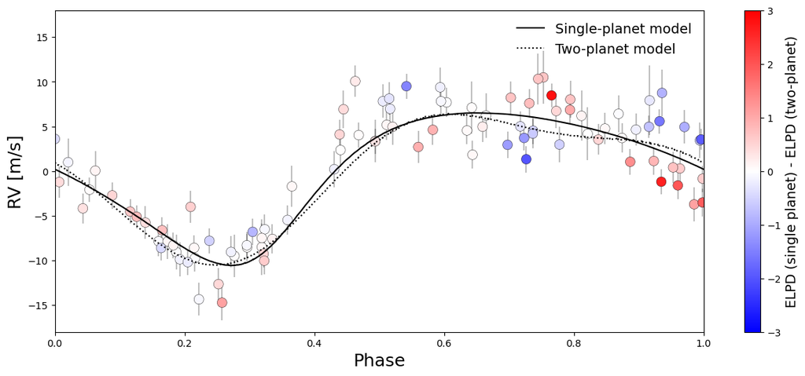

```python
rv_data = np.loadtxt('auxiliary_data/CARMENES_RV_GJ4276.dat',usecols=(0,1,2))
time = rv_data[:,0]
rv = rv_data[:,1]
err = rv_data[:,2]

period = 13.352 #Here we are using the orbital period (in days) from the single-planet solution for visualisation purposes

phase = ((time - time[0]) % period)/period

idx = np.argsort(np.abs(delta_elpd_i))

#Create figure and axis
fig = plt.figure(figsize=(15,6))
ax1 = plt.gca()

#Plot RV data, with colour set by value of delta ELPD
plt.errorbar(phase, rv,yerr=err,fmt='o',markersize=0,alpha=0.25,color='k',zorder=0.0000001)
plt.scatter(phase[idx], rv[idx] ,c=delta_elpd_i[idx],cmap='bwr',linewidth=0.3,edgecolor='k',zorder=0.1,vmin=-3,vmax=3,s=100)

#Add best-fit single-planet and two-planet models for comparison
single_planet_model = np.loadtxt('auxiliary_data/single_planet_best_fit.txt') #Format is [phase, RV]
plt.plot(single_planet_model[:,0],single_planet_model[:,1],color='k',label='Single-planet model')

two_planet_model = np.loadtxt('auxiliary_data/two_planet_best_fit.txt')
plt.plot(two_planet_model[:,0],two_planet_model[:,1],color='k',ls='dotted',label='Two-planet model')

plt.legend(fontsize=14,frameon=False)

#Add colour bar
cbar = plt.colorbar()
cbar.ax.set_ylabel('ELPD (single planet) - ELPD (two-planet)',fontsize=14)

#Axis labels and limits
ax1.set_ylabel('RV [m/s]', fontsize=18)
ax1.set_xlabel('Phase', fontsize=18)

ax1.set_xlim(0,1)
ax1.set_ylim(-18,18)
```